빅데이터를 활용한 경제 및 금융문제 분석

기말 프로젝트

재무금융전공 석사 2기 유건봉

# 1. 서론

## 1.1 주제 선정 배경

경제가 발전함에 따라 자금의 가치를 보증 및 증가하려는 욕구가 증가하고 있다.중국에 부동산 투자열이 점점 떨어지고 있기 때문에 부동산 시장에 예치된 자금은 필연적으로 부동산 시장에서 자본 시장으로 이전된다. 증권 시장의 급속한 발전과 함께 복잡하고 다양한 투자 대상으로 인해 인위적이고 주관적인 투자 방법의 효율성이 점차 감소한다. 기본적인 양적 투자는 최근 몇 년 동안 금융 기술 및 양적 투자 연구에서 새로운 핫스팟이다. 인공 지능의 대표적인 기술인 머신러닝은 경제 및 경영 분야에서 예측 연구의 효과를 크게 향상시킬 수 있다.

## 1.2 선행 연구 및 목적

# 2. 본론

## 2.1 연구모형

③ ②단계의 예측을 바탕으로 단면을 기준으로 주식을 분류하여 기대수익률이 가장 좋은 10% 주식을 매수하고 가장 나쁜 주식을 10% 매도하는 롱숏 포트폴리오를 구성한다. 동일한 가중치로 할당된다.

④ 포트폴리오를 한 달간 보유하고 2011년 1월 포트폴리오의 투자수익을 얻는다.

⑤ 2월 초부터 본 논문은 ①~④를 반복한다. 데이터 기간이 끝날 때까지 계속된다.

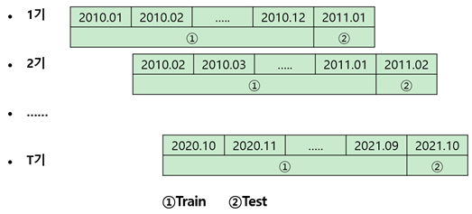

## 2.2 결과 검정 방법

논문에서는 모델의 성과를 평가하기 위해 성과 측정 지표인 모델 예측을 기반으로 롱숏 포트폴리오의 월간 수익률과 위험 조정 수익률(Fama-French 5 팩터 모형 조정 알파 및 샤프 비율 등)을 구축한다. A주 시장의 공매도 매커니즘은 충분히 유연하지 않기 때문에 본 논문에서는 롱 포트폴리오와 숏 포트폴리오로 구성한다. 그 중 롱 포트폴리오는 동일한 가중치로 예상 수익이 있는 상위 10%의 주식을 매수하고 숏 포트폴리오는 동일한 가중치로 예상 수익이 있는 하위 10%의 주식을 매도한다.

# 3. 결론

## 3.1 분석 결과

머신러닝 알고리즘과 기존의 다인자 모델을 결합하여 머신러닝 알고리즘을 기반으로 다인자 주식 선택 모델을 구성하고 머신러닝 알고리즘을 통해 각 주식을 분류하여 투자 가치가 있는 주식을 선정한다.

## 3.2 한계점

첫째, 논문에서는 주식선택모형을 구축하는 과정에서 주식 유동성 문제를 고려하지 않았다. 주식 유동성 문제로 실제 거래 시 주가 제한으로 인해 주식을 매수할 수 없는 상황이 있을 수 있다. 따라서 실제 모델을 사용함에 있어 주식 유동성 문제도 고려해야 한다.

# 4. 참고논문

[1] 李斌，机器学习驱动的基本面量化投资研究,中国工业经济，2019

[2] 李杰，基于随机森林算法的多因子选股模型研究[D]，哈尔滨工业大学，2019

코드 링크연결